# QTM 151 - Quiz 5

## Try to submit as an HTML file

Print your name below

```python
# Write your answer here

print("Robyn Jin")
```

```
Robyn Jin
```

This quiz is open book

- You can use the lecture notes
- You will get partial credit for attempting the questions
- To get full credit, the code should run as intended
- You should NOT communicate with other students

Write the following message as a comment:

"I will abide by Emory's code of conduct"

```python
# Write your own code

# I will abide by Emory's code of conduct
```

Import the libraries "matplotlib.pyplot" and "pandas"

```python
# Write your answer here

import pandas as pd
import matplotlib.pyplot as plt
```

In this quiz, we will work with a World Bank  
dataset on the proportion of urban population across  
countries, from 2016-2020.

- This is an example of a "panel"/"longitudinal" dataset  
  which contains information about the same unit (country)  
  over time.
  - This is in "long" format (see Lecture 22)

(a) Import and parse dates

- Import "data_raw/wdi_long.csv"
- Create a new column called "date" which uses `pd.to_datetime(...,format = ...)`  
  to convert year to a date format
- To get full points use wild cards to establish the format. To get full points,  
  set the "format" option using wildcards as in Lecture 20.

```python
# Write your own code

wdi_long = pd.read_csv("data_raw/wdi_long.csv")
wdi_long["date"] = pd.to_datetime(wdi_long["year"], format = "%Y")
```

(b) Plot multiple time series

- Sort `wdi_long` by `country_name` and `year` in ascending order.  
  Call this new dataset, `wdi_sorted`

HINT: See Lecture 10a for how to sort. You can sort by multiple  
variables by entering them as a list `[[...]]`

NOTE: Sorting is very important when using time series data,  
particularly for plotting and data cleaning, since observations are ordered  
in sequence from earliest to latest.

```python
# Write your own code

wdi_sorted = wdi_long.sort_values(["country_name","year"], ascending = True)
```

(c) Flag subset of data and plot

- For the sorted dataset, subset all entries of `wdi_sorted` from part (b)  
  where `country_name` to equal `"United States"` using `.query()`.  
  Call this new dataset `wdi_usa`
- Create a line plot with year on the x-axis and `prop_urban` on the y-axis
- Label the x-axis, the y-axis, and the title

HINT: You can use `.query()` to subset to "United States" by using  
escape characters, e.g. `country_name == \"United States\"`.  
See Lecture 10a for how to use query.

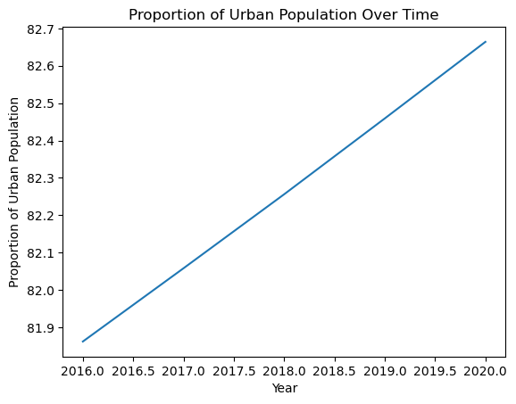

```python
# Write your own code

wdi_usa = wdi_sorted.query('country_name == \"United States\"')

plt.plot("year", "prop_urban",
         data = wdi_usa)
plt.xlabel("Year")
plt.ylabel("Proportion of Urban Population")
plt.title("Proportion of Urban Population Over Time")
plt.show()
```

(d) Obtain yearly growth rates by country

- For this question you will use `wdi_sorted` that you created in part (b)
- Use `.groupby()`, `.diff()`, and `.shift()` to compute  
  the yearly growth rates in the urban population by country.
- Store your results in a new column of `wdi_sorted` called  
  `growth_prop_urban`.

HINT: See Lecture 22

```python
wdi_sorted["prop_urban"]
```

```
0       25.020
217     25.250
434     25.495
651     25.754
868     26.026
         ...
216     32.296
433     32.237
650     32.209
867     32.210
1084    32.242
Name: prop_urban, Length: 1085, dtype: float64
```

```python
# Write your own code

wdi_sorted["diff_prop_urban"] = (wdi_sorted["prop_urban"].groupby("country_name")
                                 .diff())
wdi_sorted["lag_prop_urban"] = wdi_sorted["prop_urban"].shift(1)
wdi_sorted["growth_prop_urban"] = (wdi_sorted["diff_prop_urban"]/wdi_sorted["lag_prop_urban"])* 100
```

[output not shown]

(e) Obtain average yearly growth rates

- This question follows-up to part (d).
- Use `.groupby()`, `.agg()` to compute the average of `growth_prop_urban`

HINT: See Lecture 14 for how to compute grouped statistics.

```python
# Write your own code

year_config = pd.Grouper(key = 'date', freq = 'y')
wdi_sorted.groupby(year_config).agg(year_mean = ("growth_prop_urban", "mean")).reset_index()
```

|  | date | year_mean |
| --- | --- | --- |
| 0 | 2016-12-31 | 20.142411 |
| 1 | 2017-12-31 | 0.609406 |
| 2 | 2018-12-31 | 0.616170 |
| 3 | 2019-12-31 | 0.622746 |
| 4 | 2020-12-31 | 0.629699 |

(f) Convert dataset to wide format

- Convert "wdi_sorted" from long to wide, using the following arguments:

  ```
   index = 'country_name'
   columns = 'year'
   values =  'prop_urban'
  ```

- Display the dataset to check that it is in wide format

HINT: See Lecture 22 for details on how to use `pd.pivot()`

```python
# Write your own code

wdi_sorted_wide = pd.pivot(wdi_sorted,
                          index = 'country_name',
                          columns = 'year',
                          values = 'prop_urban')

wdi_sorted_wide
```

[output not shown]